# 1. Import drug screen data

gDR team

2026-06-16

1. Import drug screen data

**gDR Analysis Pipeline**

Date: 2026-06-16

Author: [gDR team](https://github.com/gdrplatform)

# 1 Introduction

This report covers the first step in the gDR analysis pipeline: importing raw data, adding descriptive metadata, and performing initial quality control (QC). The goal is to produce a clean, organized dataset that is ready for reliable dose-response analysis.

```r
library(qs2)
library(purrr)
library(data.table)
library(summarytools)
library(gDRutils)
library(gDRimport)
library(gDRcore)
library(gDR)
library(gDRplots)
```

```r
# get working directory path
wd <- getwd()
dir.create(file.path(wd, "plots"), showWarnings = FALSE, recursive = TRUE)
dir.create(file.path(wd, "gDR_data"), showWarnings = FALSE, recursive = TRUE)
```

# 2 Key Output Files

This report generates several key files that are used in the subsequent steps of the gDR pipeline.

## 2.1 Data Annotation Files (in `data_annotation/` folder):

- **`drug_annotation.csv`:** An annotation file listing all unique drugs found in the data with their annotations.
- **`cell_line_annotation.csv`:** An annotation file listing all unique cell lines found in the data with their annotations.

## 2.2 Processed gDR Data (in `gDR_data/` folder):

- **`gDR_input.qs2`:** This is the primary output of Step 1. It is a single, cleaned, and annotated `data.table` in a ‘tidy’ format, ready to be used as the input for the ‘Step 2: Data Processing’ report.

# 3 Import Raw Data into gDR and Do Manual Cleanup

This step merges experimental information from three sources: the manifest (plate metadata), template files (well layouts), and raw data files (instrument readouts). This produces the initial raw dataset for the gDR pipeline.

## 3.2 Additional Annotations

In addition to the minimum required fields, the data undergoes a transformation process where annotations are added. These annotations enhance the contextual understanding of the data and include:

- **For Cell Lines**: Information such as cell line name, primary tissue, doubling time, parental identifier, and subtype.
- **For Drugs**: Details about the drug, including its name and mechanism of action.

## 3.3 Annotation Guidelines

The process for annotating the data adheres to the guidelines specified in the gDR annotation documentation. Detailed guidelines and instructions can be found in the [gDR Annotation Documentation](https://github.com/gdrplatform/gDRcore/blob/main/vignettes/gDR-annotation.Rmd).

```r
#import data (subset: 10 cell lines from 43)
manifest <- c(
  "raw_data/manifest.xlsx"
)
treatment <- c(
  "raw_data/template.xlsx"
)
raw_data <- list.files("raw_data", pattern = "mtx17\\.csv$", full.names = TRUE)

data_imported <- import_data(manifest,
                             treatment,
                             raw_data,
                             instrument = detect_file_format(raw_data[1]))
```

## 3.4 Visual Quality Control of Plate-Level Data

### 3.4.1 **Raw Plate Data Interpretation**

Visually checking the raw plate data is a crucial quality control step to identify technical artifacts. The plots below combine a **Readout Heatmap** with **Dose Ranking** to help you spot issues quickly.

**How to Read the Plot:**

- **Background Color (Heatmap):** Represents the raw **`ReadoutValue`**. Lighter colors indicate lower signal (e.g., dead cells), while darker blue colors indicate higher signal (e.g., healthy controls).
- **Treatment Symbols (Center of Well):**
- **Symbol Shape:** Represents the **Cell Line** (e.g., Circle = Cell Line A, Square = Cell Line B).
- **Single Agent:** Represented by a **single symbol** in the center of the well.
- **Combination / Cotreatment:** Represented by **two symbols** side-by-side. The left symbol corresponds to Drug 1, and the right symbol corresponds to Drug 2.
- **Number inside Symbol:** Represents the **Dose Rank** (1 = Lowest dose, N = Highest dose). Refer to the **“Dose Key”** at the bottom of the plot for exact concentrations.

**Automated QC Flags (Borders):**

- **Red Border:** **Low Control Failure.** The control well signal is significantly below the plate average (potential edge effect or pipetting error).
- **Orange Border:** **High Signal Artifact.** The treated well signal is anomalously high, exceeding the statistical ceiling defined by controls (potential precipitation or contamination).

**What to Look For:**

1. **Spatial Patterns:** Scan the background colors for unintended gradients. For example, if all outer wells are lighter than the center, this often indicates an **Edge Effect** (evaporation).
2. **Dose-Response Consistency:** Follow the numbers (1 N). For a standard inhibitor, you expect the background color to fade (signal decrease) as the dose rank increases. If dose N is darker than dose 1, check for solubility issues or outliers.
3. **Anomalies:** Identify isolated wells that deviate from their neighbors (e.g., a dark spot in a white region) or rows/columns that show a “striping” effect due to liquid handling issues.

```r
plate_vis <- plot_plate_stack_info(data_imported)
```

### Plate visualization split by variable and barcode

#### 3.4.1.1 E77903mtx17

🔍 Zoom In for Details

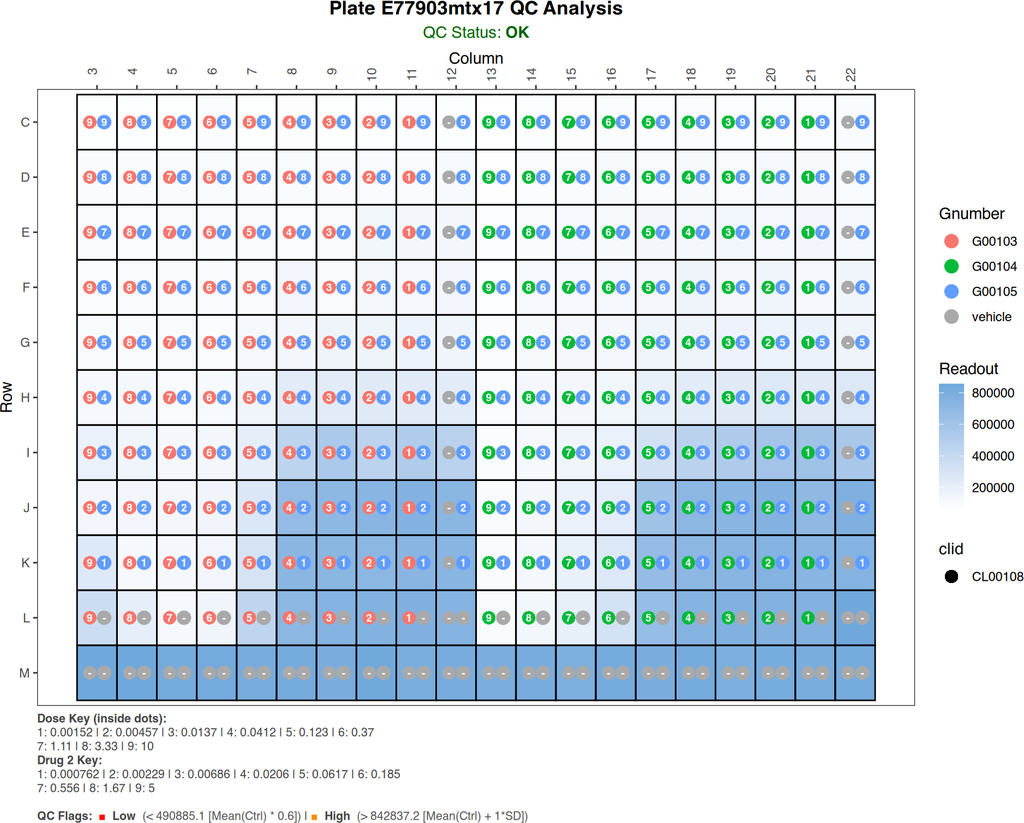

#### 3.4.1.2 E87903mtx17

🔍 Zoom In for Details

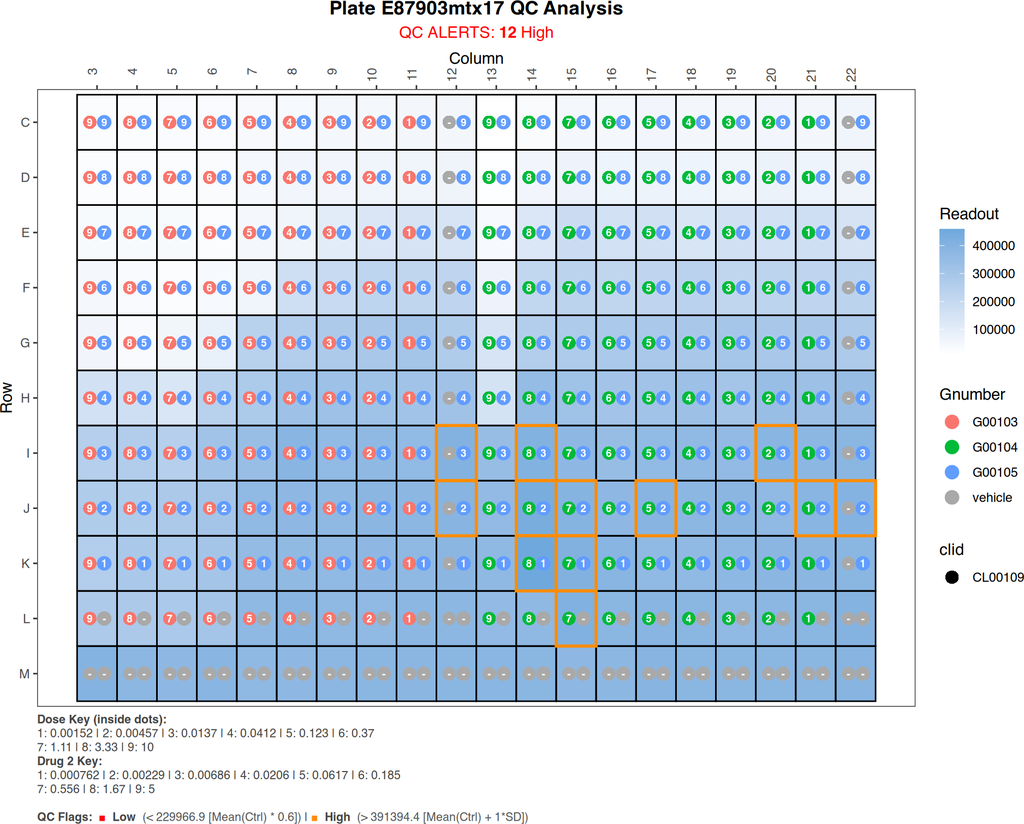

#### 3.4.1.3 H19908mtx17

🔍 Zoom In for Details

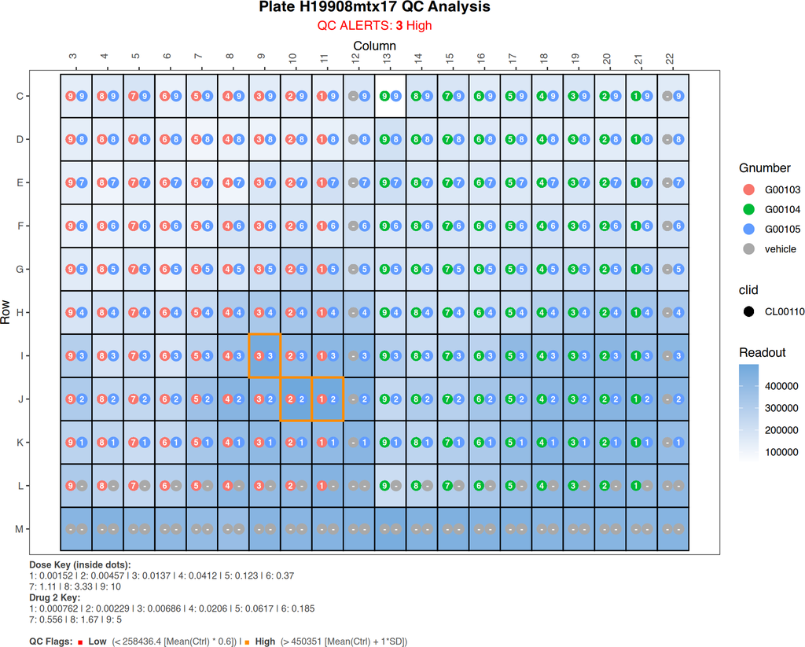

#### 3.4.1.4 K11915mtx17

🔍 Zoom In for Details

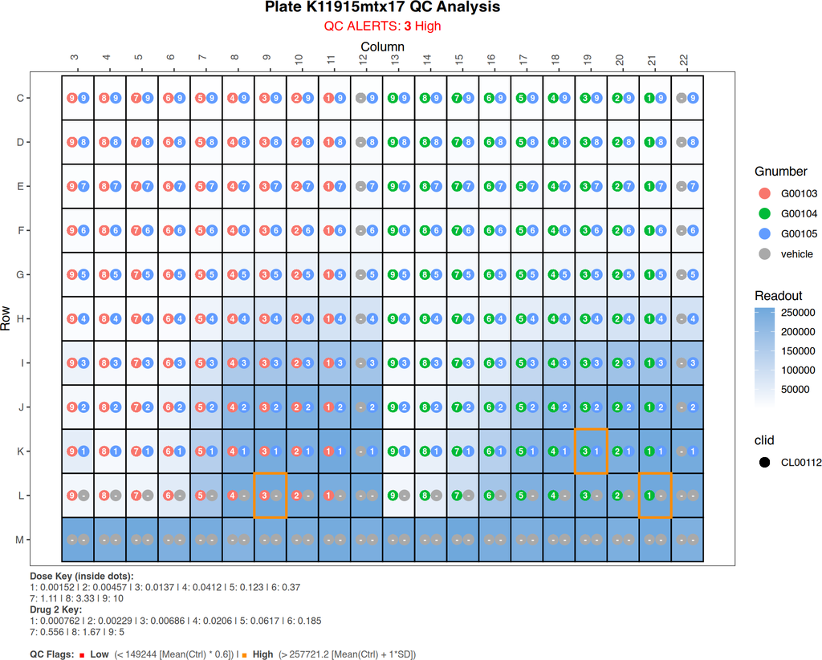

#### 3.4.1.5 K03915mtx17

🔍 Zoom In for Details

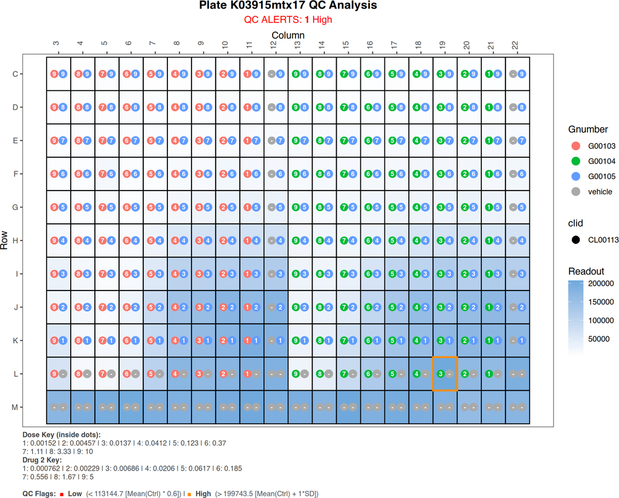

#### 3.4.1.6 H26908mtx17

🔍 Zoom In for Details

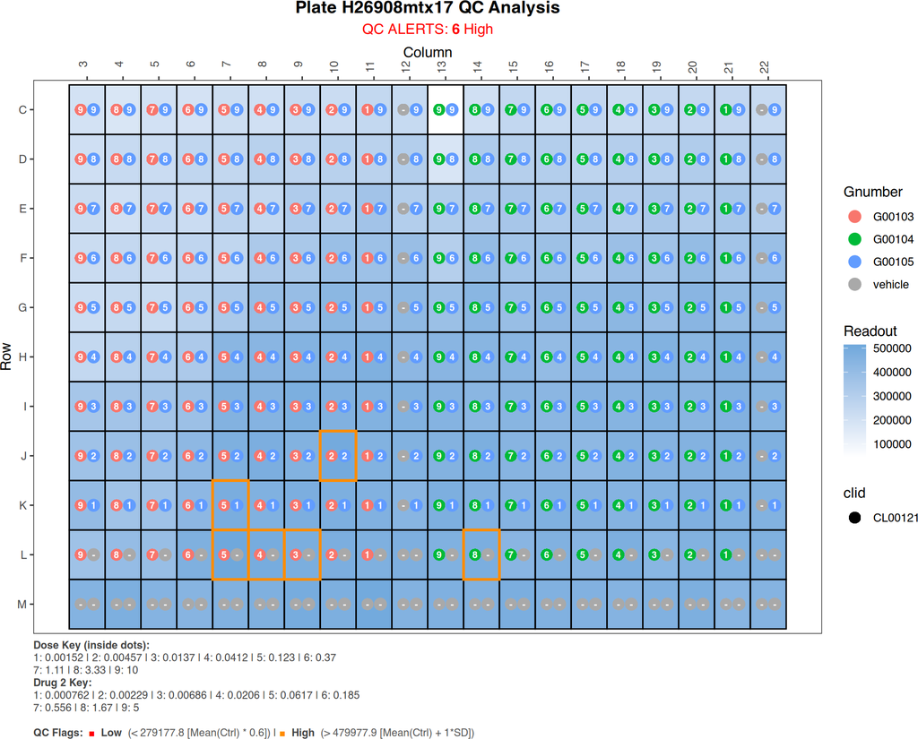

#### 3.4.1.7 H09915mtx17

🔍 Zoom In for Details

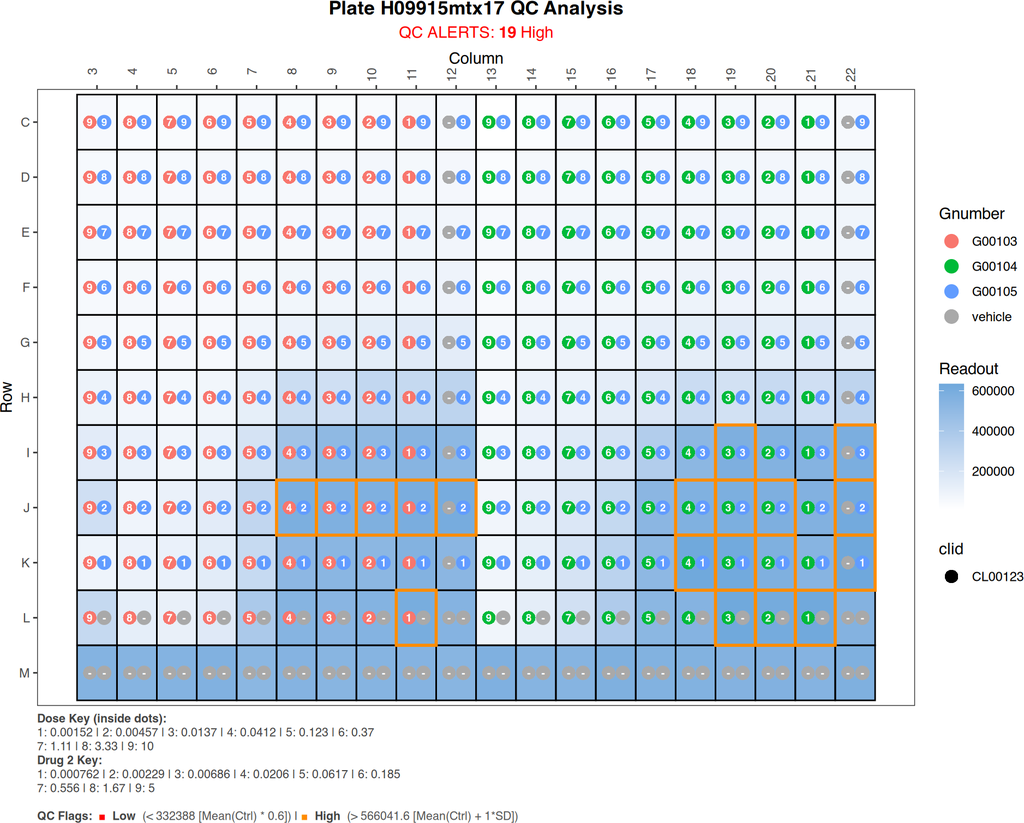

#### 3.4.1.8 E79903mtx17

🔍 Zoom In for Details

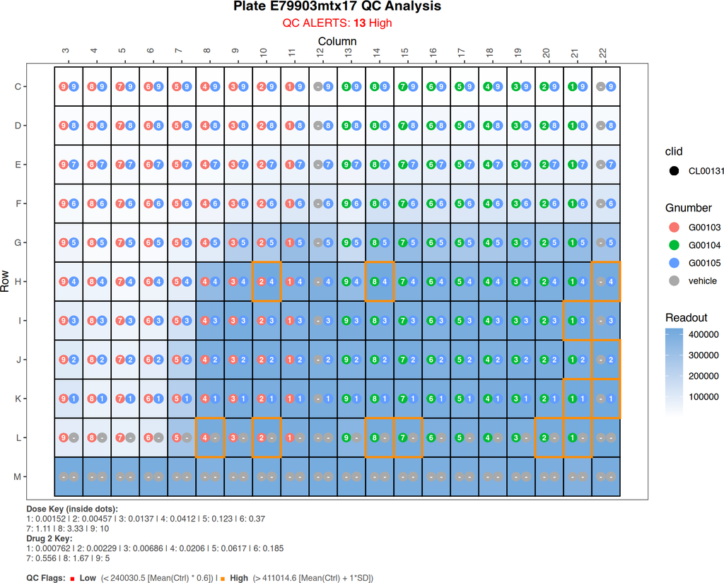

#### 3.4.1.9 E86903mtx17

🔍 Zoom In for Details

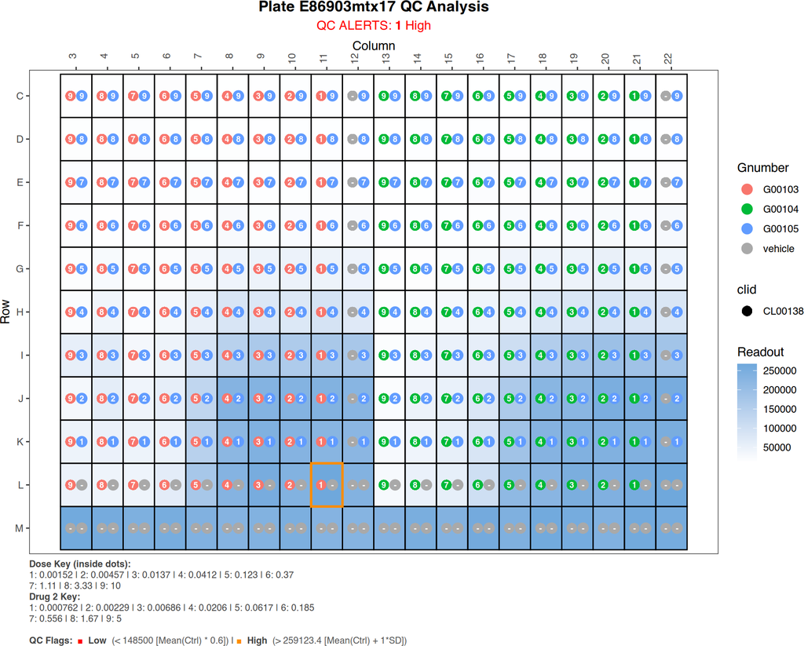

#### 3.4.1.10 H24908mtx17

🔍 Zoom In for Details

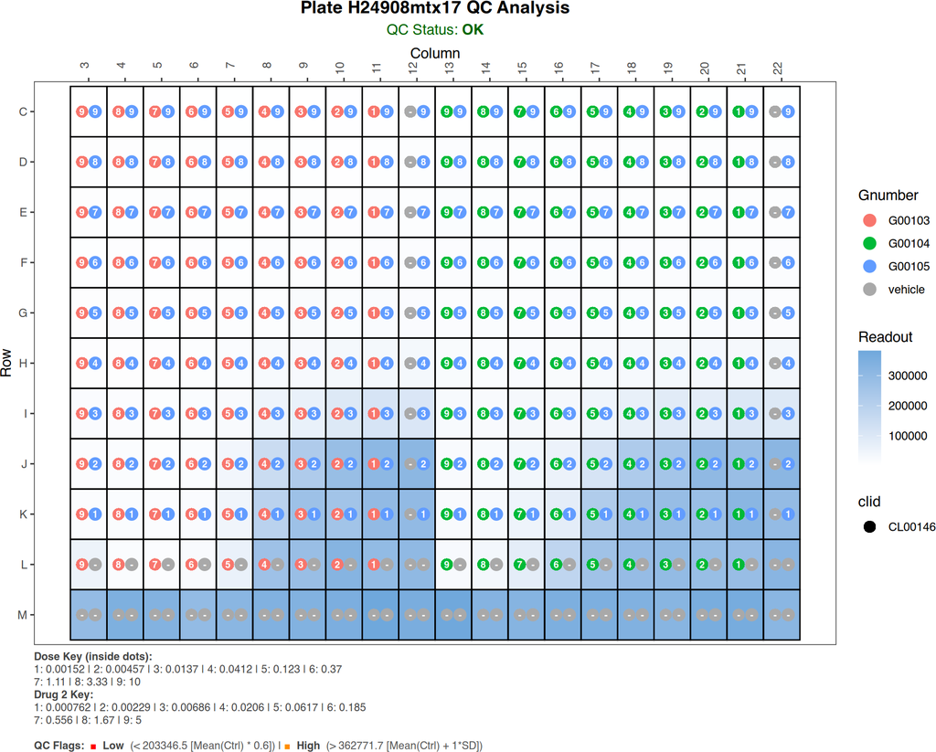

Before executing the pipeline, there exists a provision for manual alterations within the raw data. This allows for the manual modification of certain annotations and the correction of data as needed.

```r
# preview the annotation used in the preprocessing
drug_annotation_path <- file.path(wd, "data_annotation", "drug_annotation.csv")
drug_annotation <- if (file.exists(drug_annotation_path)) {
  fread(drug_annotation_path)
} else {
  get_drug_annotation_from_dt(data_imported)
}
data_imported <- annotate_dt_with_drug(data_imported, drug_annotation)
fwrite(drug_annotation, drug_annotation_path)
generate_datatable(drug_annotation)
```

|  | Gnumber | DrugName | drug_moa |
| --- | --- | --- | --- |
| 1 | G00103 | Belvarafenib | BRAF\|RAF1\|ARAF |
| 2 | G00104 | Vemurafenib | BRAF |
| 3 | G00105 | Cobimetinib | MAP2K1\|MAP2K2 |

```r
cell_line_annotation_path <- file.path(wd, "data_annotation", "cell_line_annotation.csv")
cell_line_annotation <- if (file.exists(cell_line_annotation_path)) {
  fread(cell_line_annotation_path)
} else {
  get_cellline_annotation_from_dt(data_imported)
}
data_imported <- annotate_dt_with_cell_line(data_imported, cell_line_annotation)
fwrite(cell_line_annotation, cell_line_annotation_path)
generate_datatable(cell_line_annotation)
```

|  | clid | CellLineName | Tissue | parental_identifier | subtype | ReferenceDivisionTime |
| --- | --- | --- | --- | --- | --- | --- |
| 1 | CL00108 | A-375 | Skin | A-375 | Melanoma | 25 |
| 2 | CL00109 | A-431 | Skin | A-431 | Carcinoma Squamous Cell | 30 |
| 3 | CL00110 | A2058 | Skin | A2058 | Melanoma | 18 |
| 4 | CL00112 | COLO 800 | Skin | COLO 800 | Melanoma | 45 |
| 5 | CL00113 | COLO 829 | Skin | COLO 829 | Melanoma | 56 |
| 6 | CL00121 | HSC-1 | Skin | HSC-1 | Carcinoma Squamous Cell | 57 |
| 7 | CL00123 | HT-144 | Skin | HT-144 | Melanoma | 57 |
| 8 | CL00131 | MEL-JUSO | Skin | MEL-JUSO | Melanoma | 29 |
| 9 | CL00138 | SK-MEL-28 | Skin | SK-MEL-28 | Melanoma | 39 |
| 10 | CL00146 | WM-266-4 | Skin | WM-266-4 | Melanoma | 29 |

```r
qs_save(data_imported, file.path(wd, "gDR_data", "gDR_input.qs2"))
```

# 4 Imported Data Summary

The table below summarizes the final, annotated dataset. This serves as a final check for data integrity. Key areas for review are:

- **Unique Values (`n_distinct`):** Confirms that the number of unique drugs, cell lines, and other identifiers matches the experimental design.
- **Missing Data (`% Miss`):** Look at the percentage of missing data in important columns like `ReadoutValue`.
- **Data Distribution:** Check the small histograms to see if the range and spread of your numeric data look reasonable.

```r
print(dfSummary(data_imported,
                varnumbers = FALSE,
                valid.col = FALSE,
                graph.magnif = 0.8,
                max.distinct.values = 50,
                max.string.width = 50,
                display.labels = FALSE),
      method = "render")
```

Data Frame Summary

data_imported

**Dimensions**: 2200 x 21  
**Duplicates**: 0

| **Variable** | **Stats / Values** | **Freqs (% of Valid)** | **Graph** | **Missing** |
| --- | --- | --- | --- | --- |
| clid [character] | 1. CL00108 2. CL00109 3. CL00110 4. CL00112 5. CL00113 6. CL00121 7. CL00123 8. CL00131 9. CL00138 10. CL00146 | 220 ( 10.0% ) 220 ( 10.0% ) 220 ( 10.0% ) 220 ( 10.0% ) 220 ( 10.0% ) 220 ( 10.0% ) 220 ( 10.0% ) 220 ( 10.0% ) 220 ( 10.0% ) 220 ( 10.0% ) |  | 0 (0.0%) |
| CellLineName [character] | 1. A-375 2. A-431 3. A2058 4. COLO 800 5. COLO 829 6. HSC-1 7. HT-144 8. MEL-JUSO 9. SK-MEL-28 10. WM-266-4 | 220 ( 10.0% ) 220 ( 10.0% ) 220 ( 10.0% ) 220 ( 10.0% ) 220 ( 10.0% ) 220 ( 10.0% ) 220 ( 10.0% ) 220 ( 10.0% ) 220 ( 10.0% ) 220 ( 10.0% ) |  | 0 (0.0%) |
| Tissue [character] | 1. Skin | 2200 ( 100.0% ) |  | 0 (0.0%) |
| parental_identifier [character] | 1. A-375 2. A-431 3. A2058 4. COLO 800 5. COLO 829 6. HSC-1 7. HT-144 8. MEL-JUSO 9. SK-MEL-28 10. WM-266-4 | 220 ( 10.0% ) 220 ( 10.0% ) 220 ( 10.0% ) 220 ( 10.0% ) 220 ( 10.0% ) 220 ( 10.0% ) 220 ( 10.0% ) 220 ( 10.0% ) 220 ( 10.0% ) 220 ( 10.0% ) |  | 0 (0.0%) |
| subtype [character] | 1. Carcinoma Squamous Cell 2. Melanoma | 440 ( 20.0% ) 1760 ( 80.0% ) |  | 0 (0.0%) |
| ReferenceDivisionTime [integer] | Mean (sd) : 38.5 (13.7) min ≤ med ≤ max: 18 ≤ 34.5 ≤ 57 IQR (CV) : 27 (0.4) | 18 : 220 ( 10.0% ) 25 : 220 ( 10.0% ) 29 : 440 ( 20.0% ) 30 : 220 ( 10.0% ) 39 : 220 ( 10.0% ) 45 : 220 ( 10.0% ) 56 : 220 ( 10.0% ) 57 : 440 ( 20.0% ) |  | 0 (0.0%) |
| Gnumber [character] | 1. G00103 2. G00104 3. vehicle | 900 ( 40.9% ) 900 ( 40.9% ) 400 ( 18.2% ) |  | 0 (0.0%) |
| DrugName [character] | 1. Belvarafenib 2. vehicle 3. Vemurafenib | 900 ( 40.9% ) 400 ( 18.2% ) 900 ( 40.9% ) |  | 0 (0.0%) |
| drug_moa [character] | 1. BRAF 2. BRAF\|RAF1\|ARAF 3. vehicle | 900 ( 40.9% ) 900 ( 40.9% ) 400 ( 18.2% ) |  | 0 (0.0%) |
| Gnumber_2 [character] | 1. G00105 2. vehicle | 1800 ( 81.8% ) 400 ( 18.2% ) |  | 0 (0.0%) |
| DrugName_2 [character] | 1. Cobimetinib 2. vehicle | 1800 ( 81.8% ) 400 ( 18.2% ) |  | 0 (0.0%) |
| drug_moa_2 [character] | 1. MAP2K1\|MAP2K2 2. vehicle | 1800 ( 81.8% ) 400 ( 18.2% ) |  | 0 (0.0%) |
| Duration [numeric] | 1 distinct value | 120 : 2200 ( 100.0% ) |  | 0 (0.0%) |
| Concentration [numeric] | Mean (sd) : 1.4 (2.9) min ≤ med ≤ max: 0 ≤ 0 ≤ 10 IQR (CV) : 1.1 (2.1) | 10 distinct values |  | 0 (0.0%) |
| Concentration_2 [numeric] | Mean (sd) : 0.7 (1.4) min ≤ med ≤ max: 0 ≤ 0 ≤ 5 IQR (CV) : 0.6 (2.1) | 10 distinct values |  | 0 (0.0%) |
| Barcode [character] | 1. E77903mtx17 2. E79903mtx17 3. E86903mtx17 4. E87903mtx17 5. H09915mtx17 6. H19908mtx17 7. H24908mtx17 8. H26908mtx17 9. K03915mtx17 10. K11915mtx17 | 220 ( 10.0% ) 220 ( 10.0% ) 220 ( 10.0% ) 220 ( 10.0% ) 220 ( 10.0% ) 220 ( 10.0% ) 220 ( 10.0% ) 220 ( 10.0% ) 220 ( 10.0% ) 220 ( 10.0% ) |  | 0 (0.0%) |
| Template [character] | 1. template.xlsx | 2200 ( 100.0% ) |  | 0 (0.0%) |
| ReadoutValue [numeric] | Mean (sd) : 198389.6 (183874.8) min ≤ med ≤ max: 640 ≤ 148800 ≤ 856120 IQR (CV) : 299570 (0.9) | 1903 distinct values |  | 0 (0.0%) |
| BackgroundValue [numeric] | 1 distinct value | 0 : 2200 ( 100.0% ) |  | 0 (0.0%) |
| WellRow [character] | 1. C 2. D 3. E 4. F 5. G 6. H 7. I 8. J 9. K 10. L 11. M | 200 ( 9.1% ) 200 ( 9.1% ) 200 ( 9.1% ) 200 ( 9.1% ) 200 ( 9.1% ) 200 ( 9.1% ) 200 ( 9.1% ) 200 ( 9.1% ) 200 ( 9.1% ) 200 ( 9.1% ) 200 ( 9.1% ) |  | 0 (0.0%) |
| WellColumn [character] | 1. 10 2. 11 3. 12 4. 13 5. 14 6. 15 7. 16 8. 17 9. 18 10. 19 11. 20 12. 21 13. 22 14. 3 15. 4 16. 5 17. 6 18. 7 19. 8 20. 9 | 110 ( 5.0% ) 110 ( 5.0% ) 110 ( 5.0% ) 110 ( 5.0% ) 110 ( 5.0% ) 110 ( 5.0% ) 110 ( 5.0% ) 110 ( 5.0% ) 110 ( 5.0% ) 110 ( 5.0% ) 110 ( 5.0% ) 110 ( 5.0% ) 110 ( 5.0% ) 110 ( 5.0% ) 110 ( 5.0% ) 110 (… |  | 0 (0.0%) |

Generated by summarytools 1.1.5 ([R](https://www.r-project.org/) version 4.5.1)  
2026-06-16

# 5 Conclusion

The data import and quality control step is complete. The final dataset has been saved to `gDR_data/gDR_input.qs2`.

### We Value Your Feedback!

Thank you for using gDR! We are always looking to improve, and your feedback is incredibly valuable to us.

[Share feedback or request features on GitHub](https://github.com/gdrplatform/gDRworkshops/issues)

# 6 gDR session info

```r
gdr_elapsed <- (proc.time() - gdr_start_time)[["elapsed"]]
message(sprintf("Report generated in %.1f seconds", gdr_elapsed))
gdr_sdt <- get_gDR_session_info()
generate_datatable(gdr_sdt)
```

|  | Package | Version |
| --- | --- | --- |
| 1 | gDR | 1.11.2 |
| 2 | gDRcomponents | 1.4.126 |
| 3 | gDRcore | 1.11.5 |
| 4 | gDRimport | 1.11.3 |
| 5 | gDRin | 0.2.96 |
| 6 | gDRiPlots | 0.0.24 |
| 7 | gDRplots | 0.0.111 |
| 8 | gDRsearch | 1.3.40 |
| 9 | gDRsearch2 | 0.1.100 |
| 10 | gDRtestData | 1.6.0 |

[output cut: 2 more lines]

```r
cat(sprintf("**Report generation time: %.1f seconds**", gdr_elapsed))
```

```
## **Report generation time: 17.3 seconds**
```